# Кластерный анализ

Sazykin Dmitrii

11 декабря 2017 г

## seeds

Измерения геометрических свойств ядер трех разных сортов пшеницы. [Ссылка на источник](https://archive.ics.uci.edu/ml/datasets/seeds#).

Пример исследуемых объектов

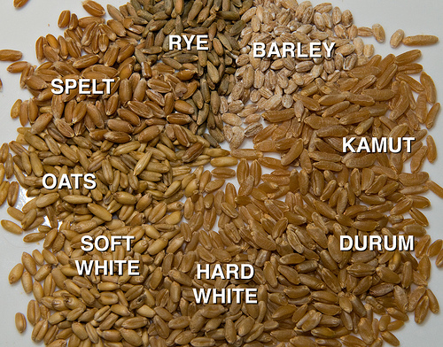

Для построения признаков были использованы следующие параметры ядер пшеницы

1. area A,
2. perimeter P,
3. compactness C = 4*pi*A/P^2,
4. length of kernel,
5. width of kernel,
6. asymmetry coefficient
7. length of kernel groove.

Описательная статистика по группам и matrixplot.

```
##
##  Descriptive statistics by group
## group: 1
##    vars  n  mean   sd   min  max range   se
## V1    1 70 -0.18 0.42 -1.24 0.77  2.01 0.05
## V2    2 70 -0.20 0.44 -1.48 0.69  2.17 0.05
## V3    3 70  0.38 0.69 -1.35 2.00  3.35 0.08
## V4    4 70 -0.27 0.52 -1.64 0.96  2.60 0.06
## V5    5 70 -0.04 0.47 -1.08 1.12  2.21 0.06
## V6    6 70 -0.69 0.78 -1.95 1.99  3.94 0.09
## V7    7 70 -0.65 0.54 -1.81 0.95  2.76 0.06
## --------------------------------------------------------
## group: 2
##    vars  n  mean   sd   min  max range   se
## V1    1 70  1.20 0.49  0.18 2.18  1.99 0.06
## V2    2 70  1.21 0.47  0.08 2.06  1.98 0.06
## V3    3 70  0.53 0.66 -1.09 1.68  2.78 0.08
## V4    4 70  1.17 0.61 -0.60 2.36  2.96 0.07
## V5    5 70  1.11 0.49 -0.07 2.05  2.12 0.06
## V6    6 70 -0.04 0.79 -1.48 1.98  3.47 0.09
## V7    7 70  1.25 0.52 -0.54 2.32  2.86 0.06
## --------------------------------------------------------
## group: 3
##    vars  n  mean   sd   min   max range   se
## V1    1 70 -1.02 0.25 -1.46 -0.51  0.96 0.03
## V2    2 70 -1.00 0.26 -1.65 -0.47  1.18 0.03
## V3    3 70 -0.91 0.92 -2.66  1.13  3.79 0.11
## V4    4 70 -0.90 0.31 -1.65 -0.20  1.45 0.04
## V5    5 70 -1.07 0.39 -1.66 -0.07  1.59 0.05
## V6    6 70  0.72 0.89 -1.36  3.16  4.52 0.11
## V7    7 70 -0.59 0.33 -1.35  0.17  1.52 0.04
```

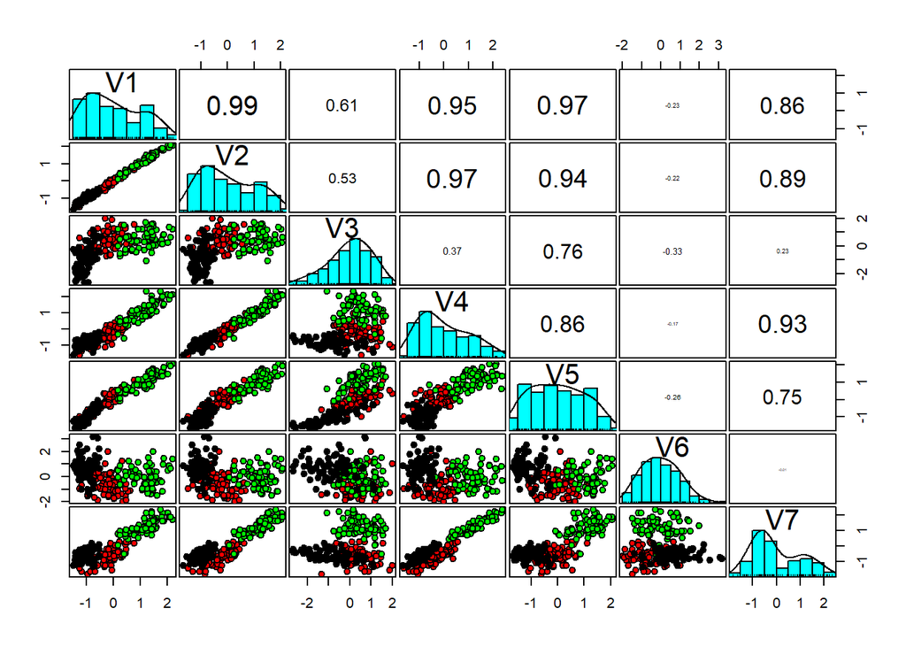

Отметим, что данные стандартизованы, так как если мы хотим объединять индивиды в группе на основе каких-то расстояний, то шкалы признаков должны быть по возможности унифицированы.

### Кластерный анализ

Цель кластерного анализа — разбить индивиды на кластеры, т.е., на группы, между которыми, в некотором смысле, расстояние больше, чем между точками внутри. Задача не формализована и, можно сказать, плохо поставлены, поэтому решается плохо.

Вообще, кластерный анализ — это ‘обучение без учителя’. Это означает, что вы не сможете формально проверить правильность результата.

Единственный вариант поставить задачу четко — это предположить какую-то стати- стическую модель данных и в ней находить параметры, например, по методу максималь- ного правдоподобия (model-based clustering).

Все остальные методы — эвристические с плохо определенным (хорошо-плохо) ре- зультатом.

#### k-means

Метод k-means является итеративным методом кластеризации. Сначала мы инициализируем центроиды (заранее заданное количество). Затем каждую точку относим к ближайшему центроиду и для получившихся кластеров пересчитываем центроиды (как центр масс), повторяем шаги, пока процесс не сойдется.

Минусы: зависит от инициализации (может найти ерунду); несложно придумать пример, когда объединение точек в шарики – не лучшая идея (вытянутые, близко лежащие эллипсоиды).

k-means++ является модификацией метода, в которой начальные расположения центроидов выбираются не совсем произвольно, что частично решает проблему инициализации.

```r
clust.km <- kmeans(df[,-8],3)
table(df[,8],clust.km$cluster)
```

```
##
##      1  2  3
##   1 62  2  6
##   2  5 65  0
##   3  4  0 66
```

#### Иерархическая кластеризация

Суть иерархической кластеризации в последовательном объединении кластеров с наименьшим межкластерным расстоянием (начинаем с числа кластеров, равного числу индивидов). В хорошем случае по дендрограмме можно увидеть наилучшее число возможных кластеров, с другой стороны, “хорошую” ситуацию можно искусственно вызвать манипуляциями с расстоянием (возведением в квадрат, например), а значит, это не самая надежная мера.

Возможные варианты межкластерного расстояния: * euclidean * maximum * manhattan * canberra * minkowski

Ниже приведен пример для евклидова межкластерного расстояния.

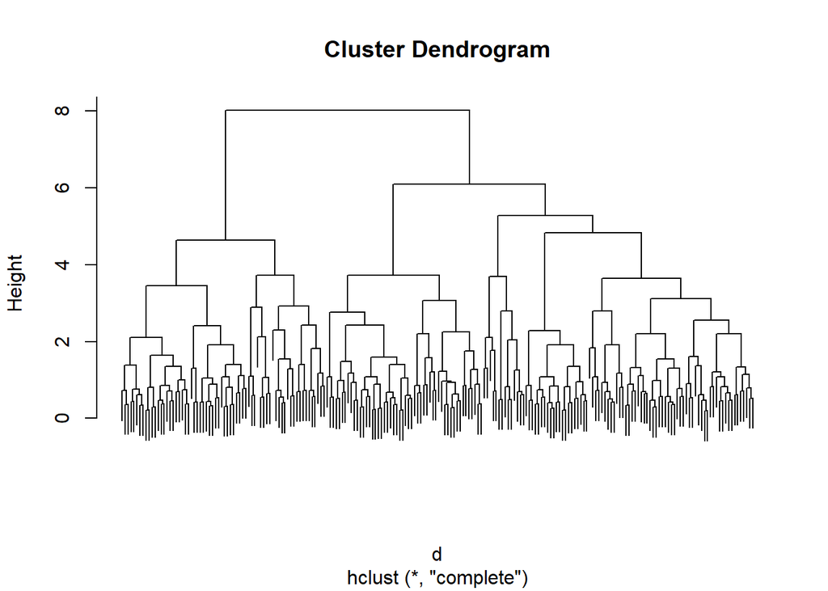

```
##
##      1  2  3
##   1 48  2 20
##   2  4 66  0
##   3  0  0 70
```

#### Model-based (package “mclust”)

В случае model-based мы предполагаем наличие модели (например, нормальной) и с помощью функции правдоподобия пытаемся решить задачу о разделении смеси (EM-алгоритм). В каком-то смысле обобщение k-means.

```r
cl.BIC <- mclustBIC(df[,-8],G = 1:4)
summary(cl.BIC)
```

```
## Best BIC values:
##             EEV,4      VEV,3      EEV,3
## BIC      179.9839   66.00606   48.81966
## BIC diff   0.0000 -113.97782 -131.16422
```

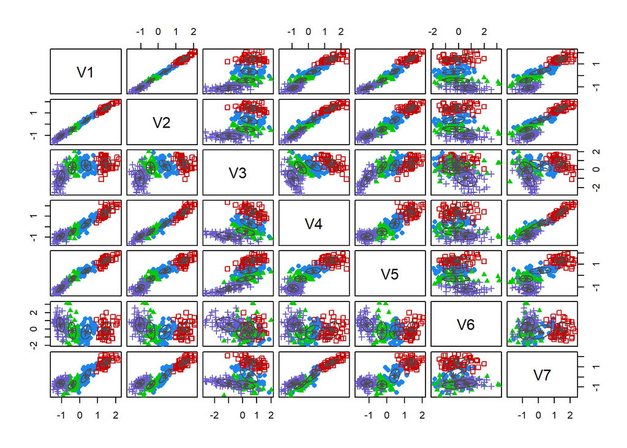

```r
fit0.mclust <- Mclust(df[,-8],modelNames = "EEV",G=4)
fit.mclust <- Mclust(df[,-8],modelNames = "VEV",G=3)
plot(fit0.mclust,what = "classification")
```

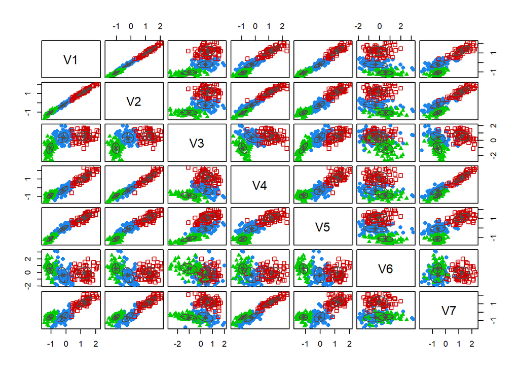

```r
plot(fit.mclust,what = "classification")
```

```r
table(df[,8],fit.mclust$classification)
```

```
##
##      1  2  3
##   1 62  4  4
##   2  5 65  0
##   3  9  0 61
```

### КА по главным компонентам

Удобно строить кластерный анализ по главным компонентам: в случае выраженных групп (кластеров), АГК обычно находит в первых компонентах различие между группами. Таким образом, во-первых, кластеризация по АГК может улучшить качество процедуры. Во-вторых, можно попробовать визуализировать первые компоненты и оценить число кластеров визуально.

Категоризующий признак в анализе не учавствовал и используется исключительно для подсветки данных. Даже не зная истинного числа групп с помощью биплота можно предположить, что их три.

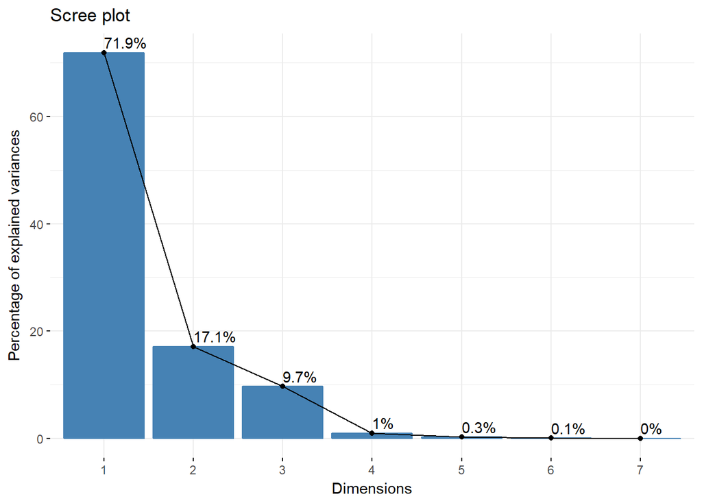

```r
pca1 <- dudi.pca(df[,-8],scannf = F, nf=8)
fviz_eig(pca1,addlabels = T)
```

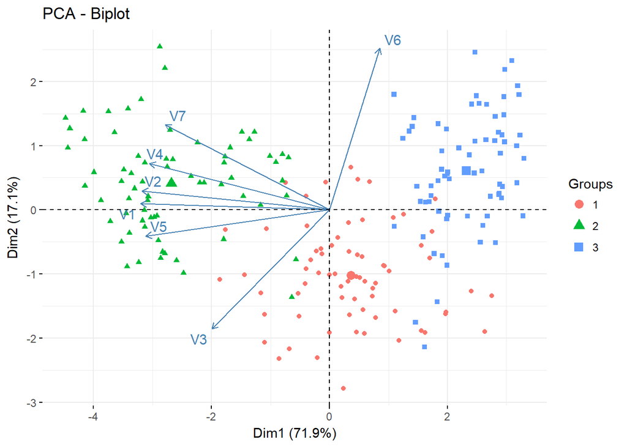

```r
fviz_pca_biplot(pca1, repel = TRUE, label = "var",habillage = df[,8])
```

В нашем случае две первых компоненты хорошо описывают наши данные.

#### k-means

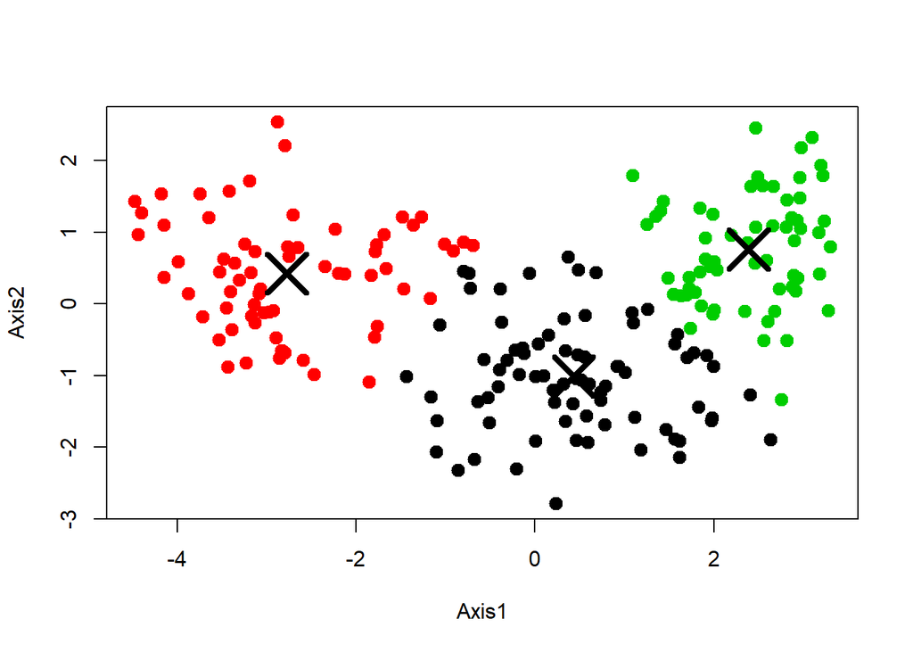

```r
Z <- pca1$li[,c(1,2)]
clust.km <- kmeans(Z,3)

plot(Z, col = clust.km$cluster,
         pch = 20, cex = 2)
points(clust.km$centers, pch = 4, cex = 4, lwd = 4)
```

```r
table(df[,8],clust.km$cluster)
```

```
##
##      1  2  3
##   1 65  2  3
##   2  4 66  0
##   3  8  0 62
```

Итоговая классификация и расположение центроидов. Для k-means качество классификации не особо изменилось, зато теперь можно наглядно посмотреть на работу алгоритма.

#### Иерархическая кластеризация.

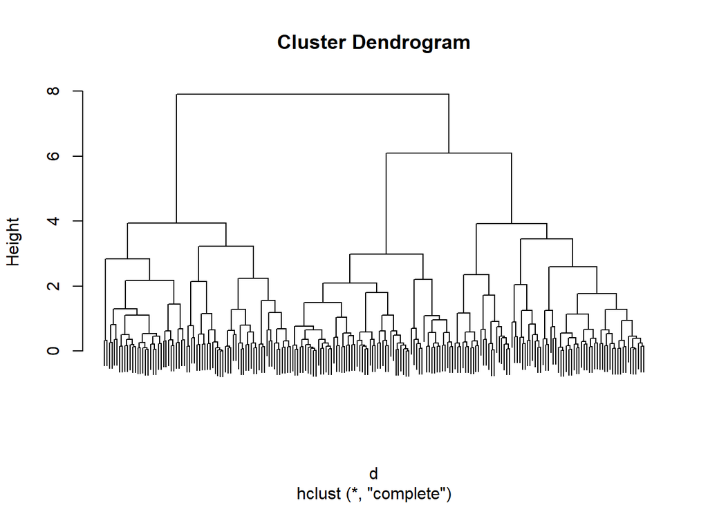

```
##
##      1  2  3
##   1 64  5  1
##   2  2 68  0
##   3  8  0 62
```

Данные хорошо разбиваются на 3 кластера. Качество классификации сильно выросло.

#### Model-based (package “mclust”)

```r
cl.BIC2 <- mclustBIC(Z,G = 1:4)
summary(cl.BIC2)
```

```
## Best BIC values:
##              EII,3        VII,3        EEI,3
## BIC      -1484.051 -1487.023305 -1487.821386
## BIC diff     0.000    -2.971834    -3.769915
```

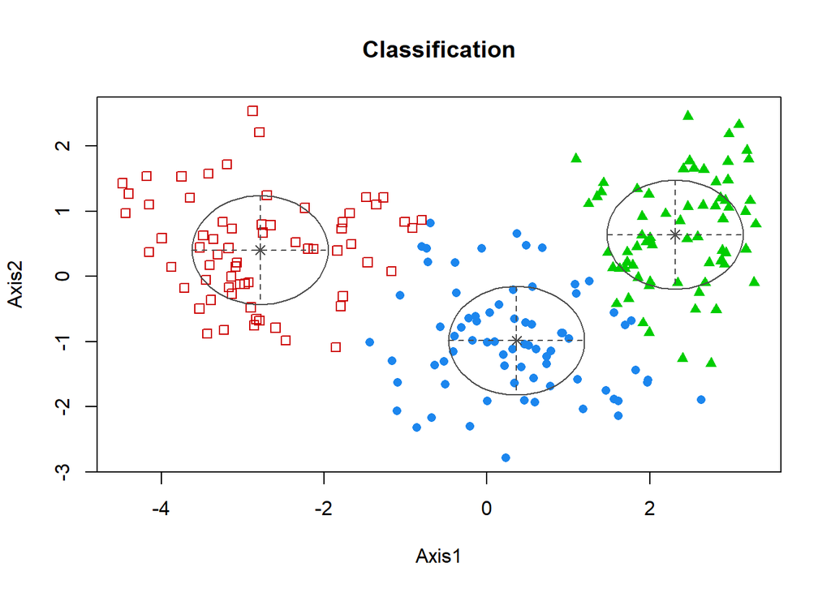

```r
fit.mclust2 <- Mclust(Z,modelNames = "EII",G = 3)
plot(fit.mclust2,what = "classification")
```

```r
table(df[,8],fit.mclust2$classification)
```

```
##
##      1  2  3
##   1 64  2  4
##   2  5 65  0
##   3  5  0 65
```